# targeted::ode_solve: Solving Ordinary Differential Equations

Klaus Kähler Holst

2023-12-19

# Introduction

Mathematical and statistical software often relies on sequential computations. **ordinary differential equations** where numerical approximations are based on looping over the evolving time. When using high-level languages such as `R` calculations can be very slow unless the algorithms can be vectorized

There are various excellent (O)DE solvers (R: [deSolve](http://desolve.r-forge.r-project.org/)) Here I will illustrate the above techniques using the `targeted` `R`-package based on [the target C++ library.](https://target.readthedocs.io/en/latest/)

The ODE is specified using the `specify_ode` function

```r
args(targeted::specify_ode)
```

```
#> function (code, fname = NULL, pname = c("dy", "x", "y", "p"))
#> NULL
```

The differential equations are here specified as a string containing the `C++` code defining the differential equation via the `code` argument. The variable names are defined through the `pname` argument which defaults to

**dy**

Vector with derivatives, i.e. the rhs of the ODE, $y'(t)$ (the result).

**x**

Vector, with the first element being the time, and the following elements additional exogenous input variables, $x(t) = \{t, x_{1}(t), \ldots, x_{k}(t)\}$

**y**

Dependent variable, $y(t) = \{y_{1}(t),\ldots,y_{l}(t)\}$

**p**

Parameter vector
$$y'(t) = f_{p}(x(t),
y(t))$$

All variables are treated as [armadillo](https://arma.sourceforge.net/) vectors/matrices, `arma::mat`.

As an example, we can specify the simple differential equation
$$y'(t) = y(t)-1$$

```r
dy <- targeted::specify_ode("dy = y - 1;")
```

This compiles the function and stores the pointer in the variable `dy`.

To solve the ODE we must then use the function `solve_ode`

```r
args(targeted::solve_ode)
```

```
#> function (ode_ptr, input, init, par = 0)
#> NULL
```

The first argument is the external pointer, the second argument `input` is the input matrix ($x(t)$ above), and the `init` argument is the vector of initial boundary conditions $y(0)$. The argument `par` is the vector of parameters defining the ODE ($p$).

# Examples

In this example the input variable does not depend on any exogenous variables so we only need to supply the time points, and the defined ODE does not depend on any parameters. To approximate the solution with initial condition $y(0)=0$, we therefore run the following code

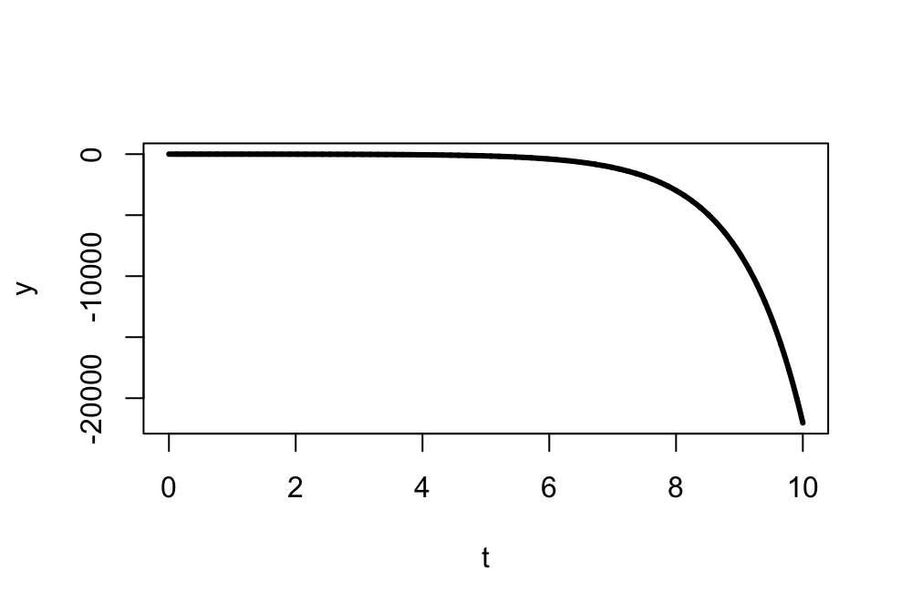

```r
t <- seq(0, 10, length.out=1e4)
y <- targeted::solve_ode(dy, t, init=0)
plot(t, y, type='l', lwd=3)
```

As a more interesting example consider the **Lorenz Equations**
$$\frac{dx_{t}}{dt} =
\sigma(y_{t}-x_{t})$$
$$\frac{dy_{t}}{dt} =
x_{t}(\rho-z_{t})-y_{t}$$
$$\frac{dz_{t}}{dt} = x_{t}y_{t}-\beta
z_{t}$$

we may define them as

```r
library(targeted)
ode <- 'dy(0) = p(0)*(y(1)-y(0));
        dy(1) = y(0)*(p(1)-y(2));
        dy(2) = y(0)*y(1)-p(2)*y(2);'
f <- specify_ode(ode)
```

With the choice of parameters given by $\sigma=10, \rho=28, \beta=8/3$ and initial conditions $(x_0,y_0,z_0)=(1,1,1)$, we can calculate the solution

```r
tt <- seq(0, 100, length.out=2e4)
y <- solve_ode(f, input=tt, init=c(1, 1, 1), par=c(10, 28, 8/3))
head(y)
```

```
#>          [,1]     [,2]      [,3]
#> [1,] 1.000000 1.000000 1.0000000
#> [2,] 1.003322 1.135177 0.9920639
#> [3,] 1.013094 1.271279 0.9849468
#> [4,] 1.029068 1.409156 0.9786954
#> [5,] 1.051048 1.549630 0.9733721
#> [6,] 1.078888 1.693496 0.9690541
```

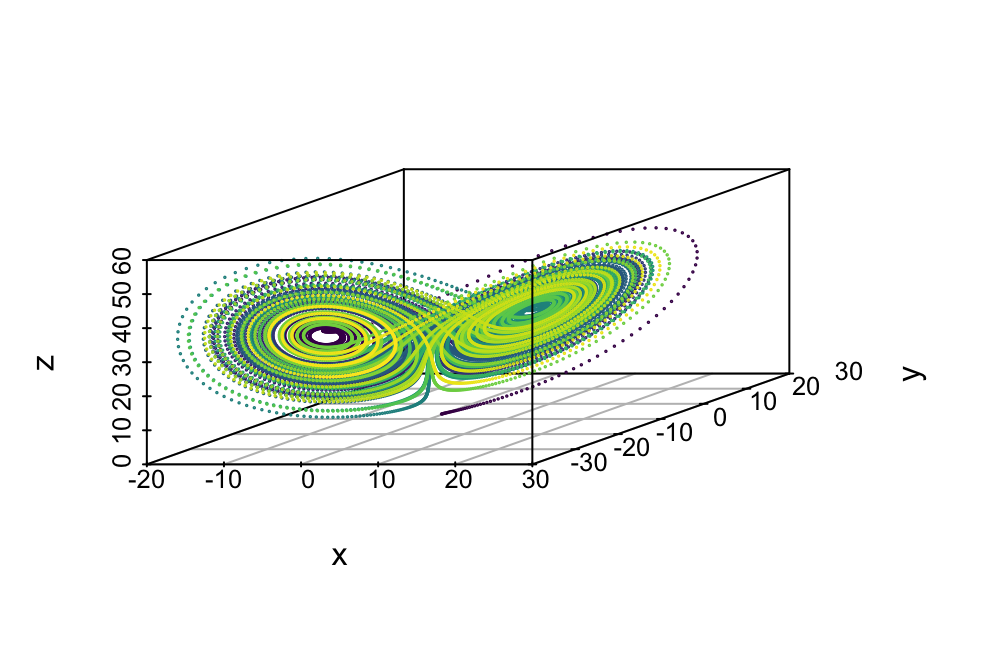

```r
colnames(y) <- c("x","y","z")
scatterplot3d::scatterplot3d(y, cex.symbols=0.1, type='b',
                             color=viridisLite::viridis(nrow(y)))
```

To illustrate the use of exogenous inputs, consider the following simulated data

```r
n <- 1e4
tt <- seq(0, 10, length.out=n)  # Time
xx <- rep(0, n); xx[(n/3):(2*n/3)] <- 1  # Exogenous input, x(t)
input <- cbind(tt, xx)
```

and the following ODE

$$y'(t) = \beta_{0} + \beta_{1}y(t) +
\beta_{2}y(t)x(t) + \beta_{3}x(t)\cdot t$$

```r
mod <- 'double t = x(0);
        dy = p(0) + p(1)*y + p(2)*x(1)*y + p(3)*x(1)*t;'
dy <- specify_ode(mod)
```

With $y(0)=100$ and $\beta_0=0, \beta_{1}=0.4, \beta_{2}=-0.5, \beta_{3}=-5$ we obtain the following solution

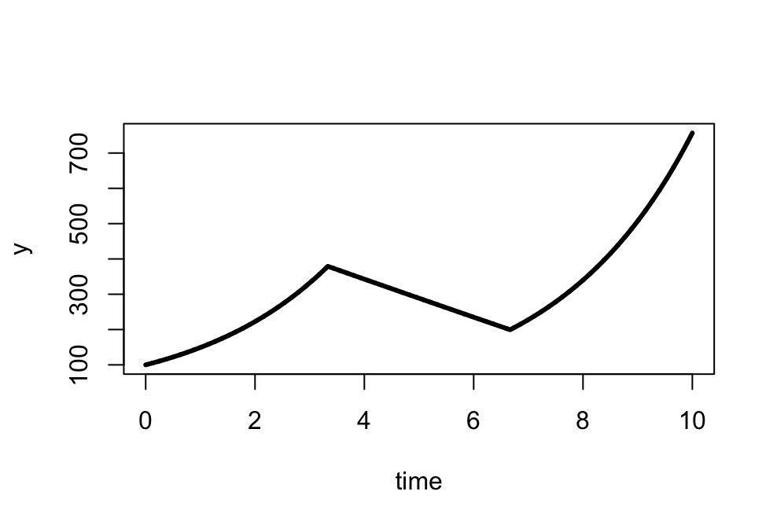

```r
yy <- solve_ode(dy, input=input, init=100, c(0, .4, -.5, -5))
plot(tt, yy, type='l', lwd=3, xlab='time', ylab='y')
```